# Mini tutorial 1

#Section 2: Color Color is a very powerful tool when creating visualizations, and many things can be decided unconsciously by the viewer of a graphic based on color. An example of this is the proper, or improper, use of the three types of color scales: sequential, this can show data across a spectrum like comparing lifespan across different countries; Diverging, which is used when there is a midpoint such as how “red” or “blue” a state voted; and un-ordered, which is when one color is not worth more or less than another color.

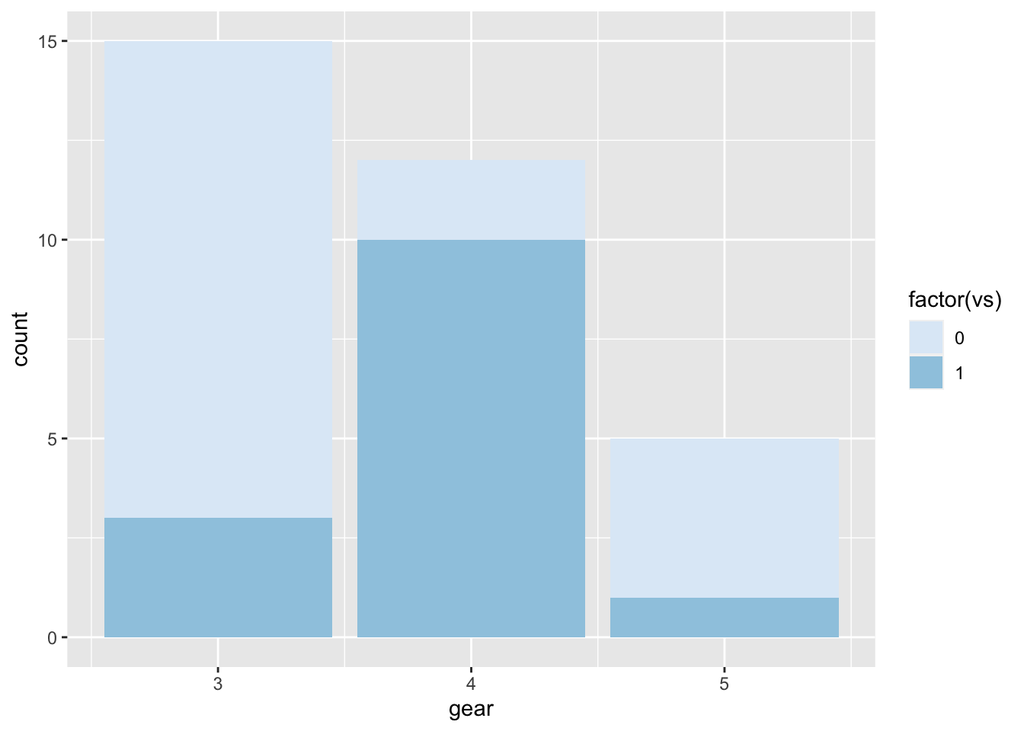

```r
ggplot(data = mtcars, mapping = aes(x = gear, fill = factor(vs)))+
  geom_bar() +
  scale_fill_brewer()
```

This plot incorrectly uses a sequential color scale when the two types of engines we are comparing are different categorical variables. To fix this we change from scale_fill_brewer() to viridis. The code below shows the same graph but with an un-ordered color scale

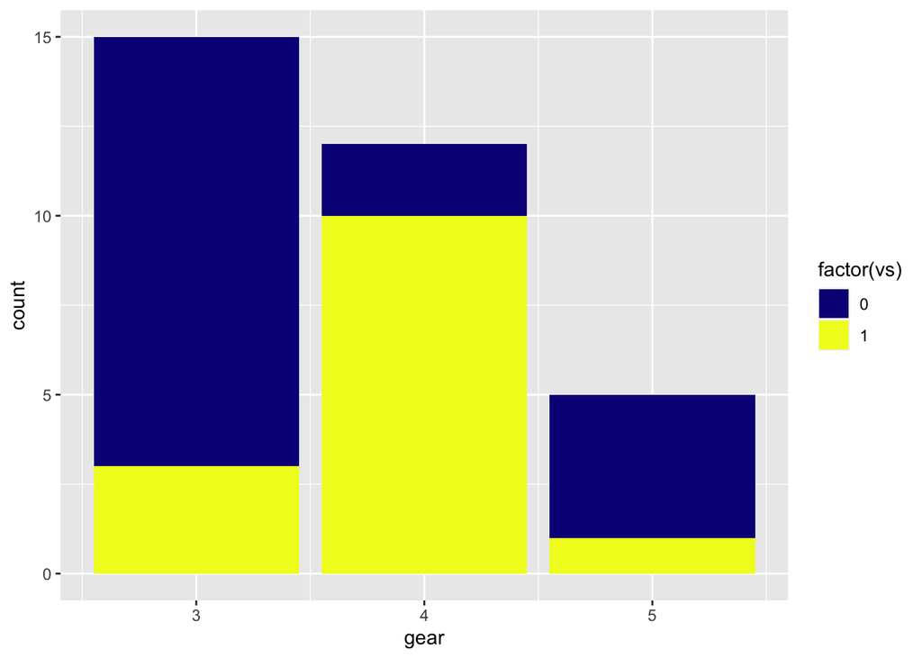

```r
ggplot(data = mtcars, mapping = aes(x = gear, fill = factor(vs)))+
geom_bar() +
scale_fill_viridis_d(option = "C")
```

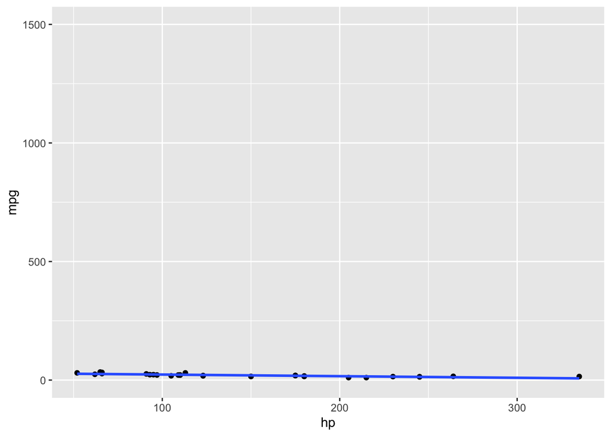

```r
ggplot(data = mtcars, mapping = aes(x = hp, y = mpg)) +
  geom_point() +
  geom_smooth(method = lm)+
    ylim(0, 1500)
```

When looking at this graphic it could be assumed that there is almost no relation between mpg and hp, however this is just because the graphic is zoomed out too far. This bad graphic could be misleading to someone who is not as advanced at reading graphics as we are, and it is not until we fix the graphic that we see how bad it truly is,

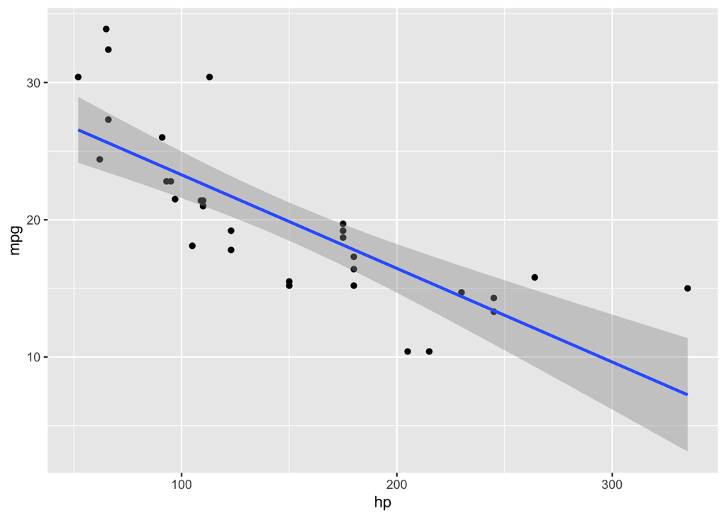

```r
ggplot(data = mtcars, mapping = aes(x = hp, y = mpg)) +
  geom_point() +
  geom_smooth(method = lm)
```

Now with the scale changed we can see how strong the relationship truly is.